# Week 4 - Assignment 3

Sally Longmore

01/02/2020

# Part 1 - Plot the 30-day Mortality Rates for Heart Attack

## Dataset

The data for this assignment comes from the Hospital Compare website (http://hospitalcompare.hhs.gov) run by the U.S. Department of Health and Human Services.

We are only looking at a small subset of the dataset for this assignment. The dataset contains the following three files.

- **outcome-of-care-measures.csv**: Contains information about 30-day mortality and re-admission rates for heart attacks, heart failure and pneumonia for over 4,000 hospitals.
- **hospotal-data.csv**: Contains information about each hospital.
- **Hospital_Revised_Flatfiles.pdf**: Descriptions of the variables in each file (i.e. the code book).

A description of variables can be found in the pdf file.

## 1. Plot the 30-day mortaility rates for heart attack

First we need to read the outcome data into r (**outcome-of-care-measures.csv**).

```r
outcome <- read.csv("outcome-of-care-measures.csv", colClasses = "character")
```

Grab the column names so we can add them back into the coerced data frame.

```r
colNameOutcome <- names(outcome)
```

Then we need to coerce the numeric columns into numeric class.

```r
loadOutcomes <- function(){
    ## Read the csv data
    outcome <- read.csv("outcome-of-care-measures.csv", colClasses = "character");

    ## Capture the column names so we can re-assign them post coercing the numeric
    ## data columns to numeric class
    colNameOutcome <- names(outcome)

    ## Coerce the numeric columns to the numeric class
    outcome <- data.frame(
        outcome[,1:7],
        as.numeric(outcome[, 8]),
        outcome[, 9:10],
        as.numeric(outcome[, 11]),
        outcome[, 12],
        as.numeric(outcome[, 13]),
        as.numeric(outcome[, 14]),
        as.numeric(outcome[, 15]),
        outcome[, 16],
        as.numeric(outcome[, 17]),
        outcome[, 18],
        as.numeric(outcome[, 19]),
        as.numeric(outcome[, 20]),
        as.numeric(outcome[, 21]),
        outcome[, 22],
        as.numeric(outcome[, 23]),
        outcome[, 24],
        as.numeric(outcome[, 25]),
        as.numeric(outcome[, 26]),
        as.numeric(outcome[, 27]),
        outcome[, 28],
        as.numeric(outcome[, 29]),
        outcome[, 30],
        as.numeric(outcome[, 31]),
        as.numeric(outcome[, 32]),
        as.numeric(outcome[, 33]),
        outcome[, 34],
        as.numeric(outcome[, 35]),
        outcome[, 36],
        as.numeric(outcome[, 37]),
        as.numeric(outcome[, 38]),
        as.numeric(outcome[, 39]),
        outcome[, 40],
        as.numeric(outcome[, 41]),
        outcome[, 42],
        as.numeric(outcome[, 43]),
        as.numeric(outcome[, 44]),
        as.numeric(outcome[, 45]),
        outcome[, 46]
    )

    names(outcome) <- colNameOutcome

    outcome
}

outcome <- loadOutcomes()
```

Next lets checkout the dataset. First of all lets look at the size of the dataset.

Number of rows:

```r
nrow(outcome);
```

```
## [1] 4706
```

Number of columns:

```r
ncol(outcome)
```

```
## [1] 46
```

How much memory is consumed by the dataset in MB:

```r
print(object.size(outcome), units = "auto", standard = "SI")
```

```
## 3.1 MB
```

Lets find out the column names:

```r
names(outcome)
```

```
##  [1] "Provider.Number"
##  [2] "Hospital.Name"
##  [3] "Address.1"
##  [4] "Address.2"
##  [5] "Address.3"
##  [6] "City"
##  [7] "State"
##  [8] "ZIP.Code"
##  [9] "County.Name"
## [10] "Phone.Number"
## [11] "Hospital.30.Day.Death..Mortality..Rates.from.Heart.Attack"
## [12] "Comparison.to.U.S..Rate...Hospital.30.Day.Death..Mortality..Rates.from.Heart.Attack"
## [13] "Lower.Mortality.Estimate...Hospital.30.Day.Death..Mortality..Rates.from.Heart.Attack"
## [14] "Upper.Mortality.Estimate...Hospital.30.Day.Death..Mortality..Rates.from.Heart.Attack"
## [15] "Number.of.Patients...Hospital.30.Day.Death..Mortality..Rates.from.Heart.Attack"
```

[output cut: 31 more lines]

Lets look at the top 6 rows:

```r
head(outcome)
```

```
##   Provider.Number                    Hospital.Name                  Address.1
## 1          010001 SOUTHEAST ALABAMA MEDICAL CENTER     1108 ROSS CLARK CIRCLE
## 2          010005    MARSHALL MEDICAL CENTER SOUTH 2505 U S HIGHWAY 431 NORTH
## 3          010006   ELIZA COFFEE MEMORIAL HOSPITAL         205 MARENGO STREET
## 4          010007         MIZELL MEMORIAL HOSPITAL              702 N MAIN ST
## 5          010008      CRENSHAW COMMUNITY HOSPITAL        101 HOSPITAL CIRCLE
## 6          010010    MARSHALL MEDICAL CENTER NORTH    8000 ALABAMA HIGHWAY 69
##   Address.2 Address.3         City State ZIP.Code County.Name Phone.Number
## 1                           DOTHAN    AL    36301     HOUSTON   3347938701
## 2                             BOAZ    AL    35957    MARSHALL   2565938310
## 3                         FLORENCE    AL    35631  LAUDERDALE   2567688400
## 4                              OPP    AL    36467   COVINGTON   3344933541
## 5                          LUVERNE    AL    36049    CRENSHAW   3343353374
## 6                     GUNTERSVILLE    AL    35976    MARSHALL   2565718000
##   Hospital.30.Day.Death..Mortality..Rates.from.Heart.Attack
```

[output cut: 251 more lines]

We need to coerce the number columns to be numeric:

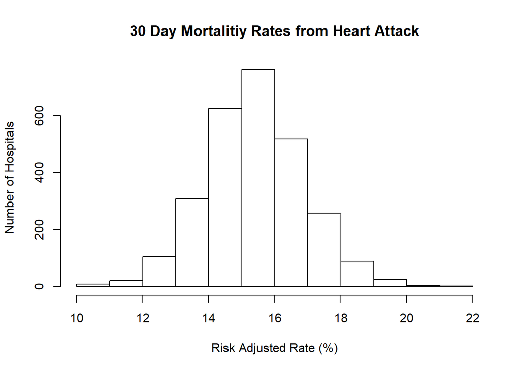

```r
hist(outcome$Hospital.30.Day.Death..Mortality..Rates.from.Heart.Attack,
     xlab = "Risk Adjusted Rate (%)",
     ylab = "Number of Hospitals",
     main = "30 Day Mortalitiy Rates from Heart Attack")
```

# Part 2 - Functing the Best Hospital in a State

Write a function called **best** that takes two arguments: 1. the 2-character abbreviated name of a state 2. an outcome name (“heart attack”, “heart failure”, “pneumonia”)

The function shuold read the outcome-of-care-measures.csv file and returns a character vector with the name of the hospital that has the best (i.e. lowest) 30-day mortality for the specified outcome in that state. The hospital name is the name provided in the **Hospital.Name** variable. Hospitals that do not have data on particular outcomes should be excluded from the set of hospitals when deciding rankings.

**Handling Ties** If there is a tie for the best hospital for a given outcome, then the hospital names should be sorted alphabetically and the first hospital in that set chosen.

```r
best <- function(state, outcome) {
    ## Turn of those warnings that are not valid
    oldWarns <- getOption("warn")
    options(warn = -1)

    ## Read the data
    source("loadOutcomes.r")
    outcomeData <- loadOutcomes()

    ## Turn the warnings back on
    options(warn = oldWarns)

        ## Check that state and outcome are valid
    ## Check if state exists first, if not then exit function with error
    state <- toupper(state) ## Convert state to upper case
    if (!(state %in% outcomeData$State)) {
        return(cat("Error in best(\"", state, "\", \"", outcome,
                   "\") : invalid state", sep = ""))
    }

    ## Remove data except from requested state
    outcomeData <- outcomeData[outcomeData$State == state, ]

    ## Check if the outcome is valid, if not then exit function with error
    outcome <- tolower(outcome) ## Convert outcome to lower case
    if (!(outcome) %in% c("heart attack", "heart failure", "pneumonia")) {
        return(cat("Error in best(\"", state, "\", \"", outcome,
                   "\") : invalid outcome", sep = ""))
    }

    ## Return hospital name in that state with lowest 30-day death rate

    ## Extract the relevant column corresponding the the requested outcome
    if (outcome == "heart attack"){
        selData <- data.frame(outcomeData$Hospital.Name, outcomeData$State,
                    outcomeData$Hospital.30.Day.Death..Mortality..Rates.from.Heart.Attack)
    } else if (outcome == "heart failure") {
        selData <- data.frame(outcomeData$Hospital.Name, outcomeData$State,
                    outcomeData$Hospital.30.Day.Death..Mortality..Rates.from.Heart.Failure)
    } else {
        selData <- data.frame(outcomeData$Hospital.Name, outcomeData$State,
                    outcomeData$Hospital.30.Day.Death..Mortality..Rates.from.Pneumonia)
    }

    ## Remove all incomplete cases from the dataset subset
    selData <- selData[complete.cases(selData), ]

    ## Find the lowest value in the dataset for the chosen outcome
    minOutcome <- min(selData[3], na.rm = TRUE)

    ## Find all the rows that have the same value as the lowest value found above
    minRows <- selData[selData[3] == minOutcome, ]

    ## Check if zero matches, one match, or more than one match is found
    if (nrow(minRows) == 0) {
        ## Zero matches, advise nothing found
        message("No results found matching requsted state and condition")
        NA
    } else if (nrow(minRows) == 1) {
        ## One match, return the match as a character vector with lenght of 1
        as.character(minRows$outcomeData.Hospital.Name)
    } else {
        ## More than one match found
        ## Sort into alphabetical order
        reordRows <- minRows[order(minRows[1]), ]
        as.character(reordRows[1, ]$outcomeData.Hospital.Name)
    }
}
```

Test this function out with a few test examples

```r
best("TX", "heart attack")
```

```
## [1] "CYPRESS FAIRBANKS MEDICAL CENTER"
```

```r
best("TX", "heart failure")
```

```
## [1] "FORT DUNCAN MEDICAL CENTER"
```

```r
best("MD", "heart attack")
```

```
## [1] "JOHNS HOPKINS HOSPITAL, THE"
```

```r
best("MD", "pneumonia")
```

```
## [1] "GREATER BALTIMORE MEDICAL CENTER"
```

```r
best("SD", "heart failure")
```

```
## [1] "AVERA HEART HOSPITAL OF SOUTH DAKOTA LLC"
```

```r
best("BB", "heart attack")
```

```
## Error in best("BB", "heart attack") : invalid state
```

```r
best("NY", "hert attack")
```

```
## Error in best("NY", "hert attack") : invalid outcome
```

# Part 3 - Ranking Hospitals by Outcome in a State

Write a function called **rankhospital** that takes three arguments:  
1. **state**: The two character abbreviated name of a state  
2. **outcome**: The medical outcome  
3. **num**: Ranking of a hospital in that state for that outcome

For example the following call:

```r
rankhospital("MD", "heart failure", 5)
```

Would return a character vector containing the name of the hospital with the 5th lowest 30-day death rate for heart failure. The **num** argument can take values **best**, **worst**, or an integer indicating the ranling (smaller numbers are better). If the number given by **num** is larger than the number of hospitals in that state, then the function should return **NA**. Hospitals that do not have data on a particular outcome should be excluded from the set of hospitals when deciding rankings.

**Handling Ties** It may occur that multiple hospitals have the same 30-day mortality rate for a given cause of death. In those cases ties should be broken by using the hospital name.

```r
rankhospital <- function(state, outcome, num = "best") {
    ## Turn of those warnings that are not valid
    oldWarns <- getOption("warn")
    options(warn = -1)

    ## ** Read the data **
    source("loadOutcomes.r")
    outcomeData <- loadOutcomes()

    ## Turn the warnings back on
    options(warn = oldWarns)

    ## ** Check that state and outcome are valid **

    ## Check if state exists first, if not then exit function with error
    state <- toupper(state) ## Convert state to upper case
    if (!(state %in% outcomeData$State)) {
        return(cat("Error in best(\"", state, "\", \"", outcome,
                   "\") : invalid state", sep = ""))
    }

    ## Remove data except from requested state
    outcomeData <- outcomeData[outcomeData$State == state, ]

    ## Check if the outcome is valid, if not then exit function with error
    outcome <- tolower(outcome) ## Convert outcome to lower case
    if (!(outcome) %in% c("heart attack", "heart failure", "pneumonia")) {
        return(cat("Error in best(\"", state, "\", \"", outcome,
                   "\") : invalid outcome", sep = ""))
    }

    ## ** Return hospital name in that state with the given rank 30-day death rate **

    ## Extract the relevant column corresponding the the requested outcome
    if (outcome == "heart attack"){
        selData <- data.frame(outcomeData$Hospital.Name, outcomeData$State,
                              outcomeData$Hospital.30.Day.Death..Mortality..Rates.from.Heart.Attack)
    } else if (outcome == "heart failure") {
        selData <- data.frame(outcomeData$Hospital.Name, outcomeData$State,
                              outcomeData$Hospital.30.Day.Death..Mortality..Rates.from.Heart.Failure)
    } else {
        selData <- data.frame(outcomeData$Hospital.Name, outcomeData$State,
                              outcomeData$Hospital.30.Day.Death..Mortality..Rates.from.Pneumonia)
    }

    ## Remove all incomplete cases from the dataset subset
    selData <- selData[complete.cases(selData), ]

    ## Handle if num set to "best" or "worst"
    if (class(num) == "character") {
        if (num == "best") {
            num <- 1;
        } else if (num == "worst") {
            num <- nrow(selData)
        }
    }

    ## Check that num does not exceed the number of hospitals in the dataset
    ## after incomplete cases removed
    if (num > nrow(selData)) {
        return(NA)
    }

    ## Re-order dataset by Risk and then Hospital Name alphabetically
    selData <- selData[order(selData[3], selData[1]), ]

    ## Select the requested rank
    as.character(selData[num, ]$outcomeData.Hospital.Name)
}
```

Now we need to test the funciton.

```r
rankhospital("TX", "heart failure", 4)
```

```
## [1] "DETAR HOSPITAL NAVARRO"
```

```r
rankhospital("MD", "heart attack", "worst")
```

```
## [1] "HARFORD MEMORIAL HOSPITAL"
```

```r
rankhospital("MN", "heart attack", 5000)
```

```
## [1] NA
```